# Bayesian template for one ordinal independent variables (line graph)

Phelan, C., Hullman, J., Kay, M. & Resnick, P.

## Introduction

Welcome! This template will guide you through a Bayesian analysis in R, even if you have never done Bayesian analysis before. This template assumes you have basic familiarity with R. Once complete, this template will produce a summary of the analysis, complete with parameter estimates and credible intervals, and two animated HOPs (see Hullman, Resnick, Adar 2015 DOI: 10.1371/journal.pone.0142444 and Kale, Nguyen, Kay, and Hullman VIS 2018 for more information) for both your prior and posterior estimates.

This set of templates supports a few types of statistical analysis. (In future work, this list of supported statistical analyses will be expanded.) For clarity, each type has been broken out into a separate template, so be sure to select the right template before you start! A productive way to choose which template to use is to think about what type of chart you would like to produce to summarize your data. Currently, the templates support the following:

*One independent variable:*

1. Categorical, bar graph (e.g. t-tests, one-way ANOVA)
2. **Ordinal, line graph (e.g. t-tests, one-way ANOVA)**
3. Continuous, line graph (e.g. linear regression)

*Two independent variables:*

4. Two categorical, bar graph (e.g. two-way ANOVA)
5. Two categorical, line graph (e.g. two-way ANOVA)
6. One categorical, one continuous (e.g. linear regression with multiple lines)

Note that this template fits your data to a model that assumes normally distributed error terms. (This is the same assumption underlying t-tests, ANOVA, etc.) This template requires you to have already run diagnostics to determine that your data is consistent with this assumption; if you have not, the results may not be valid.

Once you have selected your template, to complete the analysis, please follow along this template. For each code chunk, you may need to make changes to customize the code for your own analysis. In those places, the code chunk will be preceded by a list of things you need to change (with the heading “What to change”), and each line that needs to be customized will also include the comment #CHANGE ME within the code chunk itself. You can run each code chunk independently during debugging; when you’re finished, you can knit the document to produce the complete document.

Good luck!

## Set up

### Libraries

If this is your first time using the template, you may need to install libraries. Uncomment the lines below - install.packages() and devtools::install_github() - to install the required packages. This only needs to be done once.

```r
knitr::opts_chunk$set(cache = TRUE) #cache results of code chunks to speed up repeated knitting

# install.packages("rstanarm", "tidyverse", "tidybayes", "modelr", "devtools")
# devtools::install_github("thomasp85/gganimate")

library(rstanarm) #bayesian analysis package
library(tidyverse) #tidy datascience commands
library(tidybayes) #tidy data + ggplot workflow
library(modelr) #tidy pipelines when modelling
library(ggplot2) #plotting package
library(gganimate) #animate ggplots

theme_set(theme_light()) # set the ggplot theme for all plots
```

### Prepare data

**What to change**

1. mydata: Read in your data.

```r
mydata = read.csv("datasets/feel-the-movement_simulated-data.csv") #CHANGE ME 1
```

We’ll fit the following model: `stan_glm(y ~ x)`. As $x$ is a categorical variable in this template, this specifies a linear regression with dummy variables for each level in categorical variable $x$. **This is equivalent to ANOVA.** So for example, for a regression where $x$ has three levels, each $y_i$ is drawn from a normal distribution with mean equal to $a + b_1dummy_1 + b_2dummy_2$ and standard deviation equal to `sigma` ($\sigma$):

$$y_i \sim Normal(a + b_1dummy_1 + b_2dummy_2, \sigma)$$

Choose your independent and dependent variables. These are the variables that will correspond to the x and y axis on the final plots.

**What to change**

2. mydata$x: Select which variables will appear on the x-axis of your plots.
3. mydata$y: Select which variables will appear on the y-axis of your plots.
4. x_lab: Label your plots’ x-axes.
5. y_lab: Label your plots’ y-axes.

```r
#select your independent and dependent variable
mydata$x = mydata$tlx_scale #CHANGE ME 2
mydata$y = mydata$value #CHANGE ME 3

# label the axes on the plots
x_lab = "TLX Categories" #CHANGE ME 4
y_lab = "Score" #CHANGE ME 5
```

### Set priors

In this section, you will set priors for your model. Setting priors thoughtfully is important to any Bayesian analysis, especially if you have a small sample of data that you will use for fitting for your model. The priors express your best prior belief, before seeing any data, of reasonable values for the model parameters. The model estimation process produces a posterior distribution: beliefs about the plausible values for parameters, given the data in your dataset.

Ideally, you will have previous literature from which to draw these prior beliefs. If no previous studies exist, you can instead assign “weakly informative priors” that only minimally restrict the model; for example, a weakly informative prior for a parameter that can only have values between 1 and 7 would assign a very small probability to values outside of that range. We have provided an example of how to set priors below.

To check the plausibility of your priors, use the code section after this one to generate a graph of five sample draws from your priors to check if the values generated are reasonable.

Our model has the following parameters: a. the overall mean y-value across all levels of categorical variable x b. the mean y-value for each of the individual levels c. the standard deviation of the normally distributed error term

To simplify things when there are more than two levels for the x-variable, we limit the number of different prior beliefs you can have for the means at different x-levels. Think of the first level of the categorical variable as specifying the control condition of an experiment, and all of the other levels being treatment conditions in the experiment. We let you specify a prior belief about the plausible values of mean in the control condition, and then we let you set a prior belief about the plausible effect size. You have to specify the same plausible effect sizes for all conditions, unless you dig deeper into our code than the few spots we’ve told you to change.

To simplify things further, we only let you specify beliefs about these parameters in the form of a normal distribution. Thus, you will specify what you think is the most likely value for the parameter (the mean), and a standard deviation. You will be expressing a belief that you were 95% certain (before looking at any data) that the true value of the parameter is within two standard deviations of the mean.

Finally, our modeling system, `stan_glm()`, will automatically set priors for the last parameter, the standard deviation of the normally distributed error term for the model overall. That is almost never a model parameter that you will be interpreting, and STAN does a reasonable job of assigning weakly informative priors for that parameter in a way that it won’t have an impact on the estimation of other parameters, which we normally do care about.

**What to change**

6. a_prior: Select the control condition mean.
7. a_sd: Select the control condition standard deviation.
8. b1_prior: Select the effect size mean.
9. b1_sd: Select the effect size standard deviation.
10. You should also change the comments in the code below to explain your choice of priors.

```r
# CHANGE THIS COMMENT EXPLAINING YOUR CHOICE OF PRIORS (10)
# In our example dataset, y-axis scores can be in the range [0, 100].
# Thus, a mean value in the control condition of less than 0 or greater
# than 100 is impossible. With a normal distribution, we can't completely
# rule out those impossible values, but we choose a mean and sd that assign
# less than 5% probability to those impossible values.

a_prior = 50  # CHANGE ME 6
a_sd = 25     # CHANGE ME 7

# CHANGE THIS COMMENT EXPLAINING YOUR CHOICE OF PRIORS (10)
# In our example dataset, we do not have a strong hypothesis that the treatment
# conditions will be higher or lower than the control, so we set the mean of
# the effect size parameters to be 0. In the absence of other information, we
# set the sd to be the same as for the control condition.

b1_prior = 0  # CHANGE ME 8
b1_sd = 25    # CHANGE ME 9
```

### Check priors

Next, you’ll want to check your priors by running this code chunk. It will produce a set of five sample plots drawn from the priors you set in the previous section, so you can check to see if the values generated are reasonable. (We’ll go into the details of this code later.)

**What to change**

Nothing! Just run this code to check your priors, adjusting prior values above as needed until you find reasonable prior values. Note that you may get a couple of very implausible or even impossible values because our assumption of normally distributed priors assigns a small probability to even very extreme values. If you are concerned by the outcome, you can try rerunning it a few more times to make sure that any implausible values you see don’t come up very often.

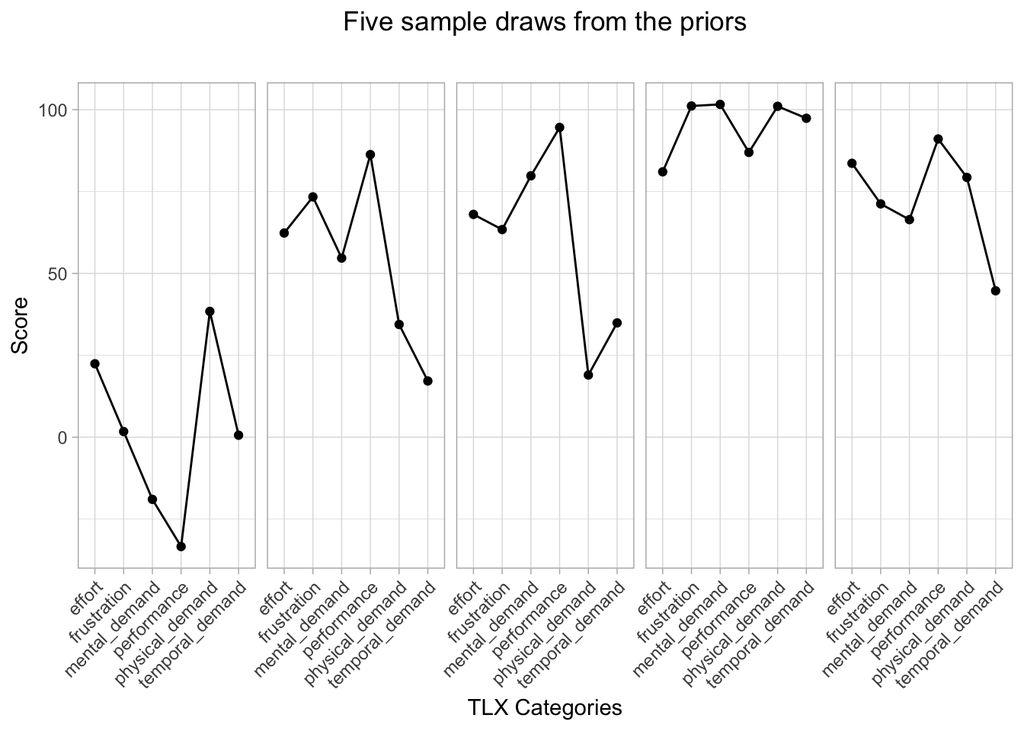

```r
#generate sample draws from the priors
m_prior = stan_glm(y ~ x, data = mydata,
  prior_intercept = normal(a_prior, a_sd, autoscale = FALSE),
  prior = normal(b1_prior, b1_sd, autoscale = FALSE),
  prior_PD = TRUE
)

#create the dataframe for fitted draws & plot the five sample draws
mydata %>%
  data_grid(x) %>%
  add_fitted_draws(m_prior, n = 5, seed = 12345) %>%
  ggplot(aes(x = x, y = .value, group=.draw)) +
  geom_line() +
  geom_point() +
  facet_grid(cols = vars(.draw)) +
  # coord_cartesian(ylim = c(min(mydata$y, na.rm=T), max(mydata$y, na.rm=T))) + # sets axis limits - CHANGE ME (optional)
  theme(strip.background = element_blank(),
        strip.text.y = element_blank(),
        axis.text.x = element_text(angle = 45, hjust = 1),
        plot.title = element_text(hjust = 0.5)) +
  labs(x=x_lab, y=y_lab) + # axes labels
  ggtitle("Five sample draws from the priors")
```

### Run the model

There’s nothing you have to change here. Just run the model.

```r
m = stan_glm(y ~ x, data = mydata,
  prior_intercept = normal(a_prior, a_sd, autoscale = FALSE),
  prior = normal(b1_prior, b1_sd, autoscale = FALSE)
)
```

## Model summary

Here is a summary of the model fit:

```r
summary(m, digits=3)
```

```
##
## Model Info:
##
##  function:     stan_glm
##  family:       gaussian [identity]
##  formula:      y ~ x
##  algorithm:    sampling
##  priors:       see help('prior_summary')
##  sample:       4000 (posterior sample size)
##  observations: 192
##  predictors:   6
##
## Estimates:
##                    mean     sd       2.5%     25%      50%      75%
## (Intercept)        63.296    1.776   59.862   62.109   63.265   64.476
## xfrustration      -14.850    2.545  -19.660  -16.547  -14.864  -13.155
## xmental_demand      4.760    2.489   -0.103    3.029    4.828    6.472
## xperformance      -10.883    2.485  -15.697  -12.546  -10.900   -9.184
## xphysical_demand  -24.431    2.504  -29.204  -26.149  -24.456  -22.831
## xtemporal_demand   -0.308    2.506   -5.067   -2.002   -0.317    1.330
## sigma              10.185    0.534    9.211    9.811   10.162   10.536
## mean_PPD           55.674    1.048   53.628   54.970   55.654   56.404
## log-posterior    -728.460    1.827 -732.869 -729.441 -728.138 -727.135
##                    97.5%
## (Intercept)        66.897
## xfrustration       -9.742
## xmental_demand      9.539
## xperformance       -6.028
## xphysical_demand  -19.380
## xtemporal_demand    4.678
## sigma              11.282
## mean_PPD           57.695
## log-posterior    -725.870
##
## Diagnostics:
##                  mcse  Rhat  n_eff
## (Intercept)      0.048 1.000 1378
## xfrustration     0.059 1.000 1836
## xmental_demand   0.060 1.001 1748
## xperformance     0.058 1.001 1804
## xphysical_demand 0.060 1.000 1749
## xtemporal_demand 0.057 1.000 1916
## sigma            0.009 1.000 3533
## mean_PPD         0.017 1.001 3775
## log-posterior    0.045 1.001 1684
##
## For each parameter, mcse is Monte Carlo standard error, n_eff is a crude measure of effective sample size, and Rhat is the potential scale reduction factor on split chains (at convergence Rhat=1).
```

## Visualizing results

To plot the results, we will first construct a *fit grid*: a data frame of points at which we want to calculate a value from the model. In this case, we have a simple fit grid: we only need to calculate a value for each level of the categorical variable $x$ in our original data. The `data_grid` function allows us to do this easily:

```r
mydata %>%
  data_grid(x)
```

```
## # A tibble: 6 x 1
##   x
##   <fct>
## 1 effort
## 2 frustration
## 3 mental_demand
## 4 performance
## 5 physical_demand
## 6 temporal_demand
```

```
## geom_path: Each group consists of only one observation. Do you need to
## adjust the group aesthetic?
```

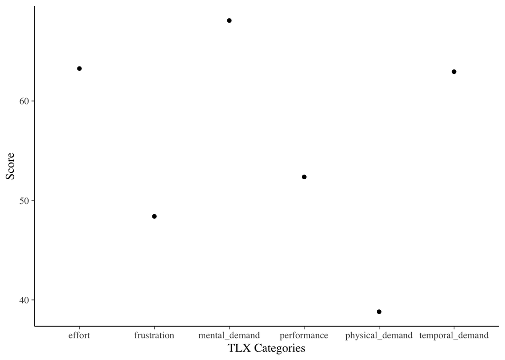

```r
#TODO Matt(?) - there must be a better way to do this.
fit = mydata %>%
      data_grid(x) %>%
      cbind(mean=m$coefficients[1]+m$coefficients) %>% #get mean estimates by adding intercept + coefficients
      cbind(sd=m$ses)
fit$mean[1] = m$coefficients[1] #replace the estimate for intercept, as above code doubles it

#TODO - this doesn't draw the lines bc there's only one observation each?
ggplot(fit, aes(x = x, y = mean)) +
    geom_line() +
    geom_point() +
    #geom_errorbar(aes(ymin=mean-sd, ymax=mean+sd), width=.2) +
    labs(x=x_lab, y=y_lab)
```

```r
#TODO Matt: this graph should be fit and not mydata, right?
#The SDs from the model are much smaller than those from below
#for the "feel the movement" dataset, the below code produces a result that looks more similar to the published graph

# ggplot(mydata, aes(x = x, y = y)) +
#     stat_summary(fun.y = mean, geom = "bar") +
#     stat_summary(fun.data = mean_sdl, geom = "errorbar", width=.2)
```

Even better would be to animate this graph using HOPs (Hypothetical Outcomes Plot), a type of plot that visualizes uncertainty as sets of draws from a distribution, which has been demonstrated to improve multivariate probability estimates (Hullman et al. 2015) and increase sensitivity to the underlying trend in data (Kale et al. 2018) over static representations of uncertainty like error bars.

To set up the HOPs plots, we will first set the aesthetics for the ggplot that we will use.

### Plot aesthetics

You can set the aesthetics of your HOPs plots here.

**What to change** In most cases, the default values here should be just fine. If you want to adjust the aesthetics of the animated plots later, you can do so here using the ggplot2 package; just be sure to keep the lines that are commented with “do not change.” Below are two optional code customizations that we think may be particularly useful for some datasets.

11. [Optional] coord_cartesian(ylim = …): You may want to manually set the y-axis limits. If so, uncomment this line in the code below and set your preferred limits accordingly.
12. [Optional] scale_x_discrete(limits = …): You may want to manually set the order of the x-axis levels; for example, if you have levels “before” and “after,” ggplot defaults often plot “after” on the left and “before” on the right. If so, uncomment this line in the code below and set your preferred level order. The names of the levels must match what is in your dataset.

```r
# the default code for the plots - if needed, the animated plot aesthetics can be customized here
graph_plot = function(data) {
  ggplot(data, aes(x = x, y = .value)) + #do not change
    geom_bar(stat='identity') + #do not change
    transition_states(.draw, transition_length = 1, state_length = 1) + # gganimate code to animate the plots. Do not change
    theme(axis.text.x = element_text(angle = 45, hjust = 1)) + #rotates the x-axis text for readability
    # coord_cartesian(ylim = c(min(mydata$y, na.rm=T), max(mydata$y, na.rm=T))) + # sets axis limits - CHANGE ME 11 (optional)
    # scale_x_discrete(limits=c("before","after")) + #manually set the order of the x-axis levels - CHANGE ME 12 (optional)
    labs(x=x_lab, y=y_lab) # axes labels
}

# Animation parameters
n_draws = 100 # the number of draws to visualize in the HOPs plots
frames_per_second = 2.5 # the speed of the HOPs
# 2.5 frames per second (400ms) is the recommended speed for the HOPs visualization.
# Faster speeds (100ms) have been demonstrated to not work as well.
# See Kale et al. VIS 2018 for more info.
```

Now that the plot aesthetics are set, we can return to our fit grid and repeatedly draw samples from the posterior mean evaluated at each x position in the grid using the `add_fitted_draws` function. Each frame of the animation shows a different draw from the posterior:

[figure not shown]

```r
p <- mydata %>% #pipe mydata to datagrid()
  data_grid(x) %>% #create a fit grid with each level in x, and pipe it to add_fitted_draws()
  add_fitted_draws(m, n = n_draws, seed = 12345) #add n fitted draws from the model to the fit grid
  # the seed argument is for reproducibility: it ensures the pseudo-random
  # number generator used to pick draws has the same seed on every run,
  # so that someone else can re-run this code and verify their output matches

#animate the data from p, using the graph aesthetics set in the graph aesthetics code chunk
animate(graph_plot(p), nframes = n_draws * 2, fps = frames_per_second)
```

## Sampling from the prior

We already looked at some sample plots of the priors when we were setting priors; now we want to look at these priors again, but in a HOPs format so we can compare to the posterior plots. To get the prior plots, we can simply ask `stan_glm` to sample from the prior. If you are knitting this document, or if you already ran the code in the “Check priors” section that calculates m_prior, you can comment out this line:

```r
#m_prior = update(m, prior_PD = TRUE)
```

Then our code to generate plots is identical, except we replace `m` with `m_prior`:

[figure not shown]

```r
p_prior = mydata %>%
  data_grid(x) %>%
  add_fitted_draws(m_prior, n = n_draws, seed = 12345)

animate(graph_plot(p_prior), nframes = n_draws * 2, fps = frames_per_second)
```